# lorenz-executed

1

actions

In [ ] markdown

[output not shown]

# The Lorenz Differential Equations

2

actions

In [ ] markdown

[output not shown]

Before we start, we import some preliminary libraries. We will also import (below) the accompanying `lorenz.py` file, which contains the actual solver and plotting routine.

3

actions

In [ 1 ] code

```
%matplotlib inline
from ipywidgets import interactive, fixed
```

Out [ 1 ]

4

actions

In [ ] markdown

[output not shown]

We explore the Lorenz system of differential equations:

$$ \begin{aligned} \dot{x} & = \sigma(y-x) \\ \dot{y} & = \rho x - y - xz \\ \dot{z} & = -\beta z + xy \end{aligned} $$

Let's change ($\sigma$, $\beta$, $\rho$) with ipywidgets and examine the trajectories.

5

actions

In [ 2 ] code

[output not shown]

Out [ 2 ]

6

actions

In [ ] markdown

[output not shown]

7

actions

In [ ] markdown

[output not shown]

The object returned by `interactive` is a `Widget` object and it has attributes that contain the current result and arguments:

8

actions

In [ 3 ] code

```
t, x_t = w.result
```

Out [ 3 ]

9

actions

In [ 4 ] code

```
w.kwargs
```

Out [ 4 ]

```
{'sigma': 10.0, 'beta': 2.6666666666666665, 'rho': 28.0}
```

10

actions

In [ ] markdown

[output not shown]

After interacting with the system, we can take the result and perform further computations. In this case, we compute the average positions in $x$, $y$ and $z$.

11

actions

In [ 5 ] code

```
xyz_avg = x_t.mean(axis=1)
```

Out [ 5 ]

12

actions

In [ 6 ] code

```
xyz_avg.shape
```

Out [ 6 ]

```
(30, 3)
```

13

actions

In [ ] markdown

[output not shown]

Creating histograms of the average positions (across different trajectories) show that, on average, the trajectories swirl about the attractors.

14

actions

In [ 7 ] code

```
from matplotlib import pyplot as plt
```

Out [ 7 ]

15

actions

In [ 8 ] code

```
plt.hist(xyz_avg[:,0])
plt.title('Average $x(t)$');
```

Out [ 8 ]

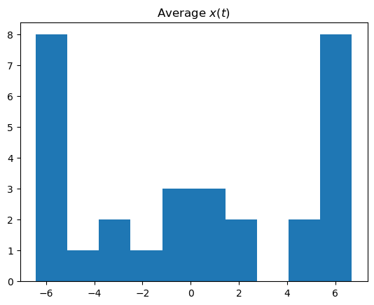

16

actions

In [ 9 ] code

```
plt.hist(xyz_avg[:,1])
plt.title('Average $y(t)$');
```

Out [ 9 ]

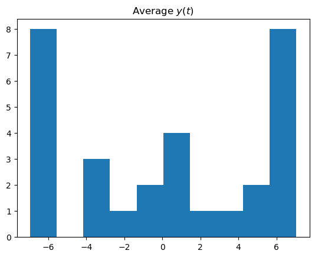